# R Notebook

Set working directory to current one

```r
library(rstudioapi)
current_path = rstudioapi::getActiveDocumentContext()$path
setwd(dirname(current_path ))
```

Import Ble dataset

```r
Ble = read.table('Dataset_Ble.txt',header=TRUE,sep=';')
attach(Ble)
```

Initial check of imported data

```r
dim(Ble)
```

```
[1] 80  4
```

```r
head(Ble)
```

|  | parcelle | variete | phyto | rdt |
| --- | --- | --- | --- | --- |
| 1 | 1 | V1 | Avec | 5652 |
| 2 | 2 | V1 | Avec | 5583 |
| 3 | 3 | V1 | Avec | 5612 |
| 4 | 4 | V1 | Avec | 5735 |
| 5 | 5 | V1 | Avec | 5704 |
| 6 | 6 | V1 | Avec | 5544 |

One-way anova influence of variete on rdt - Visual Inspection via boxplot

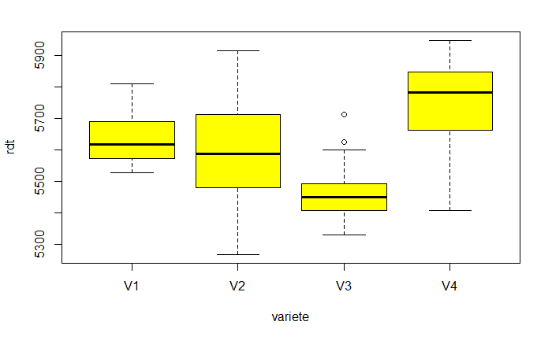

```r
boxplot(rdt~variete,col='yellow')
```

nb of observations by variete

```r
summary(variete)
```

```
V1 V2 V3 V4
20 20 20 20
```

Create model

```r
vLM = lm(rdt~variete)
```

Check assumptions on the gaussianity of the residuals

- Homogeneity of variances (leveneTest) –> LeveneTest p-value small - there is no homogeneity of variances (what to do ???)

```r
if(!require(car)) install.packages("car")
library(car)
leveneTest(vLM)
```

```
Levene's Test for Homogeneity of Variance (center = median)
      Df F value  Pr(>F)
group  3  3.2154 0.02748 *
      76
---
Signif. codes:  0 ‘***’ 0.001 ‘**’ 0.01 ‘*’ 0.05 ‘.’ 0.1 ‘ ’ 1
```

- Gaussianity (QQplot) –> QQPlot ok noise gaussian

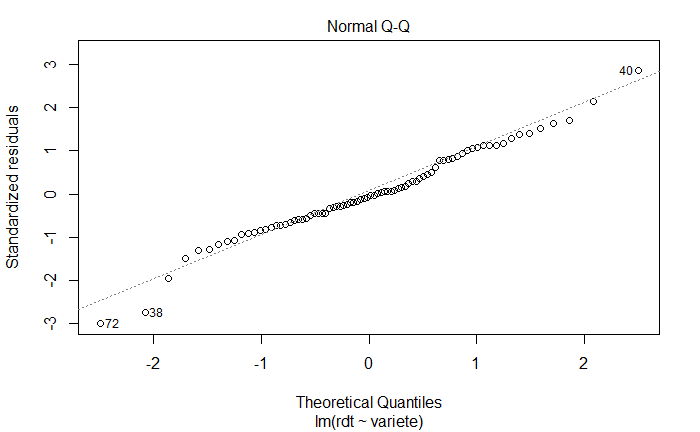

```r
plot(vLM,2)
```

Shapiro

```r
shapiro.test(vLM)
```

```
Error in shapiro.test(vLM) : is.numeric(x) is not TRUE
```

Run Anova on model –> p-value very small - there is an influence of variete on rdt

```r
AvLM = anova(vLM)
AvLM
```

```
Analysis of Variance Table

Response: rdt
          Df  Sum Sq Mean Sq F value    Pr(>F)
variete    3  851845  283948  20.525 7.674e-10 ***
Residuals 76 1051387   13834
---
Signif. codes:  0 ‘***’ 0.001 ‘**’ 0.01 ‘*’ 0.05 ‘.’ 0.1 ‘ ’ 1
```

One-way anova influence of phyto on rdt - Visual Inspection via boxplot

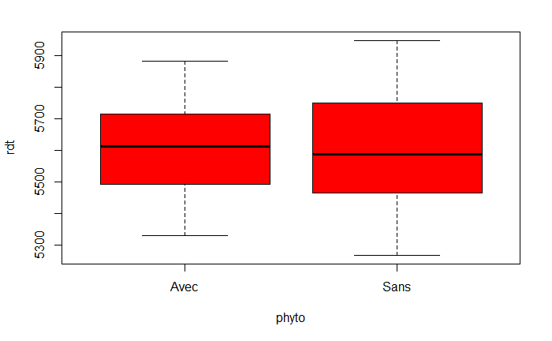

```r
boxplot(rdt~phyto,col='red')
```

nb of observations by phyto

```r
summary(phyto)
```

```
Avec Sans
  40   40
```

Create model

```r
pLM = lm(rdt~phyto)
```

Check assumptions on the gaussianity of the residuals

- Homogeneity of variances (leveneTest) –> LeveneTest p-value >0.05 - there is homogeneity of variances

```r
if(!require(car)) install.packages("car")
library(car)
leveneTest(pLM)
```

```
Levene's Test for Homogeneity of Variance (center = median)
      Df F value Pr(>F)
group  1   0.685 0.4104
      78
```

- Gaussianity (QQplot) –> QQPlot ok noise gaussian

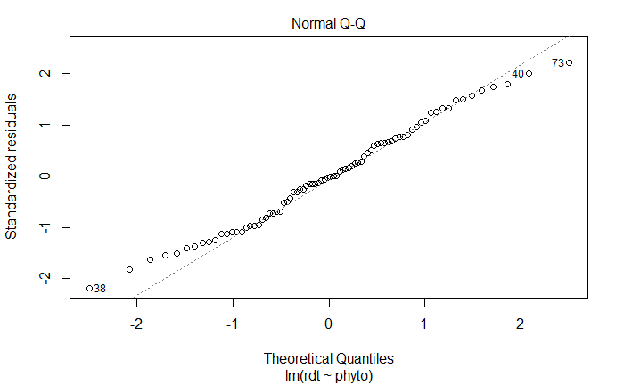

```r
plot(pLM,2)
```

Run Anova on model –> p-value very big - there is no influence of phyto on rdt

```r
ApLM = anova(pLM)
ApLM
```

```
Analysis of Variance Table

Response: rdt
          Df  Sum Sq Mean Sq F value Pr(>F)
phyto      1    1008  1008.2  0.0413 0.8394
Residuals 78 1902223 24387.5
```

Two-way anova influence of phyto/variete on rdt - Visual Inspection via boxplot

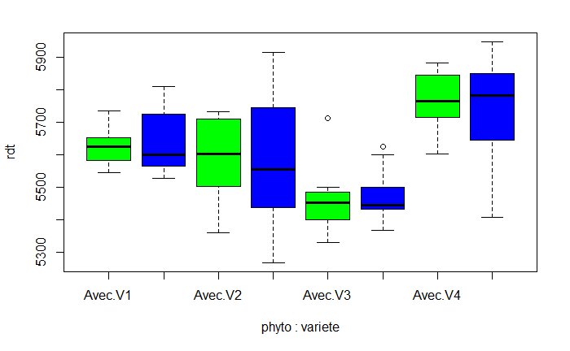

```r
boxplot(rdt ~ phyto * variete, col=c('green','blue'))
```

Create model

```r
vpLM = lm(rdt ~ phyto * variete)
```

Check assumptions on the gaussianity of the residuals

- Homogeneity of variances (leveneTest) –> LeveneTest p-value >0.05 - there is homogeneity of variances

```r
if(!require(car)) install.packages("car")
library(car)
leveneTest(vpLM)
```

```
Levene's Test for Homogeneity of Variance (center = median)
      Df F value  Pr(>F)
group  7  1.8815 0.08513 .
      72
---
Signif. codes:  0 ‘***’ 0.001 ‘**’ 0.01 ‘*’ 0.05 ‘.’ 0.1 ‘ ’ 1
```

- Gaussianity (QQplot) –> QQPlot ok noise gaussian

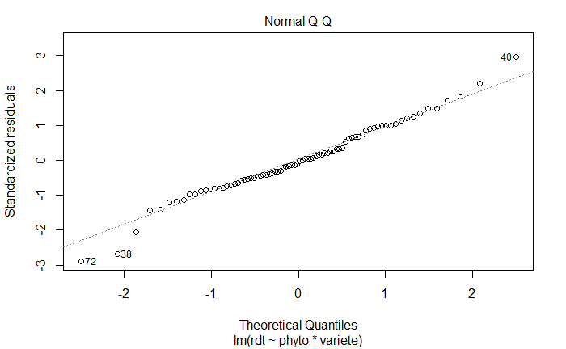

```r
plot(vpLM,2)
```

Run Anova on model –> p-value phyto:variete very big - there is no influence of cross effect of phyto/variete on rdt

```r
AvpLM = anova(vpLM)
AvpLM
```

```
Analysis of Variance Table

Response: rdt
              Df  Sum Sq Mean Sq F value    Pr(>F)
phyto          1    1008    1008  0.0695    0.7928
variete        3  851845  283948 19.5749 2.205e-09 ***
phyto:variete  3    5968    1989  0.1371    0.9375
Residuals     72 1044411   14506
---
Signif. codes:  0 ‘***’ 0.001 ‘**’ 0.01 ‘*’ 0.05 ‘.’ 0.1 ‘ ’ 1
```

Use additive model instead

```r
ADDvpLM = lm(rdt ~ phyto + variete)
```

Homgeneity of variance + normality

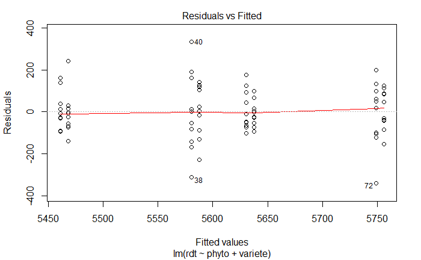

```r
plot(ADDvpLM,1)
```

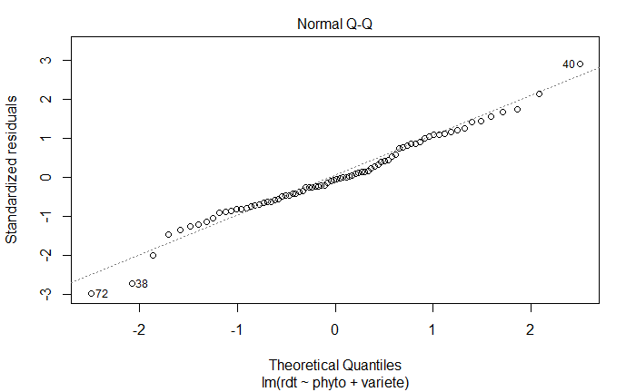

```r
plot(ADDvpLM,2)
```

Anova Result

```r
ADDAvpLM = anova(ADDvpLM)
ADDAvpLM
```

```
Analysis of Variance Table

Response: rdt
          Df  Sum Sq Mean Sq F value   Pr(>F)
phyto      1    1008    1008   0.072   0.7892
variete    3  851845  283948  20.275 1.01e-09 ***
Residuals 75 1050379   14005
---
Signif. codes:  0 ‘***’ 0.001 ‘**’ 0.01 ‘*’ 0.05 ‘.’ 0.1 ‘ ’ 1
```

TO-BE-CEHCKED

test - anova for unbalanced design (???)

```r
my_anova <- aov(rdt ~ phyto * variete)
Anova(my_anova, type = "III")
```

```
Anova Table (Type III tests)

Response: rdt
                 Sum Sq Df    F value    Pr(>F)
(Intercept)   316755096  1 21836.5908 < 2.2e-16 ***
phyto               650  1     0.0448    0.8330
variete          474473  3    10.9031 5.487e-06 ***
phyto:variete      5968  3     0.1371    0.9375
Residuals       1044411 72
---
Signif. codes:  0 ‘***’ 0.001 ‘**’ 0.01 ‘*’ 0.05 ‘.’ 0.1 ‘ ’ 1
```

Others

Pairwise

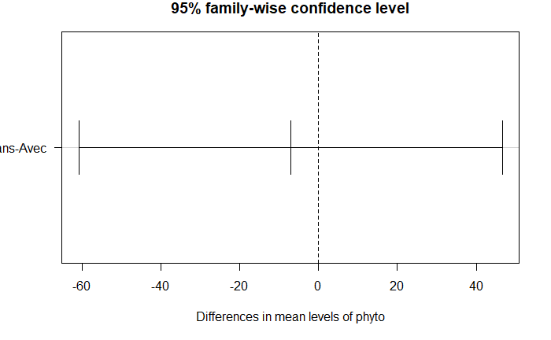

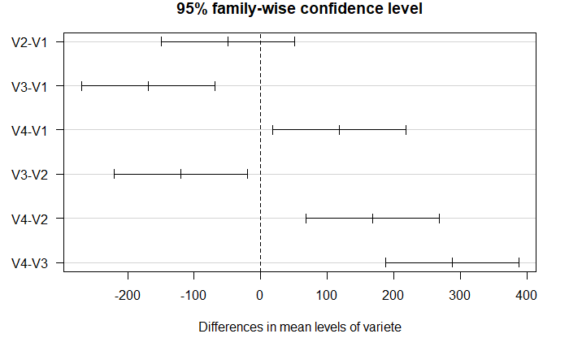

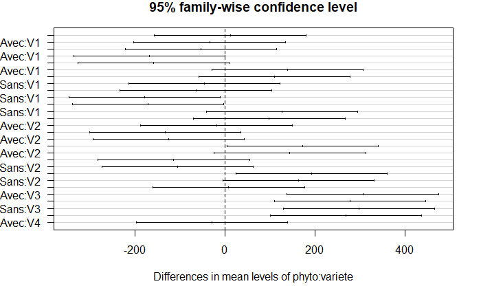

```r
vpAOV = aov(rdt ~ phyto * variete)
par(las=1)
plot(TukeyHSD(vpAOV))
```